# Stacked Model for Cutaneous Leishmaniasis

Lyndsey Umsted

2022-07-27

Loading Neccessary Libraries

```r
library(tidyverse)
library(tidymodels)
library(stacks)
library(pROC)
```

Loading the Annual Amazon Data Set and Tidying it by removing any NA values for Cutaneuous Leishmaniasis along with any case reportings of 0.

```r
getwd()
```

```
## [1] "C:/Users/18586/Desktop/Summer Disease Internship/MacDonald-REU-Summer-22/models"
```

```r
aad <- read.csv("data/aad.csv")
aad <-subset(aad, aad$Cutaneous.Leishmaniasis > 0)
aad <- subset(aad, !is.na(aad$Cutaneous.Leishmaniasis))
aad <-subset(aad, aad$Year < 2019)
```

Separating the data into two separate data sets, one for data before 2014 (early_data) and one for data after 2013 (later_data), and then tidying it while removing unnecessary columns.

```r
library(dplyr)
early_data <- aad %>%
  filter(Year < 2014)
later_data <- aad %>%
  filter(Year > 2013)

early_data <- early_data %>%
  select(-c("AvgRad"))
later_data <- later_data %>%
  select(-c("StableLights"))
```

Reducing columns to desired Predicitive Variables: Population, LAST_Day, Precip, AvgRad, SWOccurrence, NDVI, EVI, pland_forest, te_forest, enn_mn_forest.

```r
later_data_small <- later_data %>%
  select(c("Population", "Cutaneous.Leishmaniasis", "LST_Day", "Precip", "AvgRad", "SWOccurrence", "NDVI", "EVI", "pland_forest", "te_forest", "enn_mn_forest"))
later_data_small <- subset(later_data_small, !is.na(later_data_small$LST_Day))
later_data_small <- subset(later_data_small, !is.na(later_data_small$SWOccurrence))
```

Converting all NA values in pland_forest, te_forest, and enn_mn_forest to 0.

```r
later_data_small$pland_forest <- ifelse(is.na(later_data_small$pland_forest),
                                        0, later_data_small$pland_forest)
later_data_small$te_forest <- ifelse(is.na(later_data_small$te_forest),
                                     0, later_data_small$te_forest)
later_data_small$enn_mn_forest <- ifelse(is.na(later_data_small$enn_mn_forest),
                                         0, later_data_small$enn_mn_forest)
```

Creating new dataset cat_df where values of Cutaneous.Leishmaniasis are split at the 30th percentile threshold and categorized into low and high risk labels.

```r
library(dplyr)
summary(later_data_small$Cutaneous.Leishmaniasis)
```

```
##     Min.  1st Qu.   Median     Mean  3rd Qu.     Max.
##  0.00054  0.08493  0.26759  0.96817  0.81716 81.89952
```

```r
cat_df <- later_data_small
cat_df$Cutaneous.Leishmaniasis <- cut(later_data_small$Cutaneous.Leishmaniasis,
                                      breaks = c(0, 0.11703435, 10^3),
                                      labels = c("low", "high")) # median


skimr::skim(cat_df)
```

Data summary

| Name | cat_df |
| --- | --- |
| Number of rows | 13121 |
| Number of columns | 11 |
| _______________________ |  |
| Column type frequency: |  |
| factor | 1 |
| numeric | 10 |
| ________________________ |  |
| Group variables | None |

**Variable type: factor**

| skim_variable | n_missing | complete_rate | ordered | n_unique | top_counts |
| --- | --- | --- | --- | --- | --- |
| Cutaneous.Leishmaniasis | 0 | 1 | FALSE | 2 | hig: 8992, low: 4129 |

**Variable type: numeric**

| skim_variable | n_missing | complete_rate | mean | sd | p0 | p25 | p50 | p75 | p100 | hist |
| --- | --- | --- | --- | --- | --- | --- | --- | --- | --- | --- |
| Population | 0 | 1 | 51906.02 | 276571.94 | 161.00 | 6692.00 | 14359.00 | 31389.00 | 10275006.00 | ▇▁▁▁▁ |
| LST_Day | 0 | 1 | 28.30 | 3.81 | 11.75 | 26.31 | 28.63 | 31.01 | 42.91 | ▁▂▇▅▁ |
| Precip | 0 | 1 | 1495.39 | 797.58 | 8.95 | 949.48 | 1399.10 | 1875.27 | 7701.10 | ▇▅▁▁▁ |
| AvgRad | 0 | 1 | 1.03 | 3.89 | -0.04 | 0.10 | 0.23 | 0.49 | 102.65 | ▇▁▁▁▁ |
| SWOccurrence | 0 | 1 | 35.86 | 22.89 | 0.00 | 16.97 | 31.00 | 52.00 | 97.94 | ▇▇▅▃▂ |
| NDVI | 0 | 1 | 0.60 | 0.11 | 0.08 | 0.55 | 0.62 | 0.67 | 0.85 | ▁▁▂▇▂ |
| EVI | 0 | 1 | 0.38 | 0.08 | 0.04 | 0.34 | 0.40 | 0.44 | 0.56 | ▁▁▃▇▃ |
| pland_forest | 0 | 1 | 15.36 | 27.93 | 0.00 | 0.00 | 0.00 | 19.79 | 99.82 | ▇▁▁▁▁ |
| te_forest | 0 | 1 | 2735870.23 | 7585312.86 | 0.00 | 0.00 | 0.00 | 1856550.00 | 125918460.00 | ▇▁▁▁▁ |
| enn_mn_forest | 0 | 1 | 29.67 | 100.84 | 0.00 | 0.00 | 0.00 | 60.06 | 5730.72 | ▇▁▁▁▁ |

```r
round(prop.table(table(cat_df$Cutaneous.Leishmaniasis)), 2)
```

```
##
##  low high
## 0.31 0.69
```

Creating Testing and Training sets for our base models.

```r
set.seed(123) # for reproducibility

split <- initial_split(cat_df)

data_train <- training(split)
data_test <- testing(split)


data_train <-subset(data_train, data_train$Population < 4000000)
data_train <-subset(data_train, data_train$Precip < 6000)
data_train <-subset(data_train, data_train$LST_Day < 37)
data_train <-subset(data_train, data_train$LST_Day > 17)
data_train <-subset(data_train, data_train$AvgRad < 50)
data_train <-subset(data_train, data_train$NDVI > 0.2)
data_train <-subset(data_train, data_train$EVI > 0.1)
data_train <-subset(data_train, data_train$pland_forest > 0)
data_train <-subset(data_train, data_train$te_forest > 0)
data_train <-subset(data_train, data_train$enn_mn_forest > 0)
data_train <-subset(data_train, data_train$enn_mn_forest < 3000)


# use a 5-fold cross-validation
folds <- rsample::vfold_cv(data_train, v = 5)
```

Creating basic recipe defining both predictor and target variables, along with definig a minimal workflow and metric for all the base models.

```r
# set up a basic recipe
data_rec <-
  recipe(Cutaneous.Leishmaniasis ~ Population + LST_Day + NDVI +
           EVI + Precip + AvgRad + SWOccurrence + pland_forest +
           te_forest + enn_mn_forest, data = data_train) %>%
  step_dummy(all_nominal() - all_outcomes()) %>%
  step_zv(all_predictors())

# define a minimal workflow
data_wflow <-
  workflow() %>%
  add_recipe(data_rec)

# add metric rmse (same as malaria)
metric <- metric_set(recall, accuracy) #.784 for roc_auc
```

```r
library(stacks)

# save assessment set predictions and workflow used to fit the resamples
ctrl_grid <- control_stack_grid()
ctrl_res <- control_stack_resamples()

# models: SVM, XGBoost, RF
## models to try: logistic regression

# toy model
log_reg_spec <-
  logistic_reg() %>%
  set_engine('glm')

log_reg_wflow <-
  data_wflow %>%
  add_model(log_reg_spec)

set.seed(123)
log_reg_res <-
  fit_resamples(
    log_reg_wflow,
    resamples = folds,
    metrics = metric,
    control = ctrl_res
  )
```

```
## ! Fold4: preprocessor 1/1, model 1/1: glm.fit: fitted probabilities numerically 0 or 1 occurred
```

Setting up Support Vector Machine base model:

```r
# define svm model using parsnip
svm_spec <-
  svm_rbf(
    cost = tune(),
    rbf_sigma = tune()
  ) %>%
  set_engine('kernlab') %>%
  set_mode('classification')

# add it to a workflow
svm_wflow <-
  data_wflow %>%
  add_model(svm_spec)

# tune cost and rbf_sigma and fit to the 10-fold cv
set.seed(123)
svm_res <-
  tune_grid(
    svm_wflow,
    resamples = folds,
    grid = 5,
    control = ctrl_grid
  )

save(svm_res, file = 'stacking/svm_res_later_classif_2')
#load(file = 'models/stacking/svm_res_later_classif_2')
```

Setting up XGBoost base model:

```r
# define xgboost model using parsnip

set.seed(123)
xgb_spec <-
  boost_tree(
    mtry = tune(),
    trees = tune(),
    min_n = tune(),
    tree_depth = tune(),
    learn_rate = tune(),
    loss_reduction = tune()
  ) %>%
  set_engine('xgboost') %>%
  set_mode('classification')

# add it to a workflow
xgb_wflow <-
  data_wflow %>%
  add_model(xgb_spec)

# tune mtry, trees, min_n, tree_depth, etc.
xgb_res <-
  tune_grid(
    xgb_wflow,
    resamples = folds,
    grid = 5,
    control = ctrl_grid
  )
```

```
## i Creating pre-processing data to finalize unknown parameter: mtry
```

```r
save(xgb_res, file = 'stacking/xgb_res_later_classif_2')

#load(file = 'models/stacking/xgb_res_later_classif_2')
```

Setting up Random Forest base model:

```r
# define rf model using parsnip

set.seed(123)
rf_spec <-
  rand_forest(
    mtry = tune(),
    trees = tune(),
    min_n = tune()
  ) %>%
  set_engine('ranger') %>%
  set_mode('classification')

# add it to a workflow
rf_wflow <-
  data_wflow %>%
  add_model(rf_spec)

# tune mtry, trees, min_n
rf_res <-
  tune_grid(
    rf_wflow,
    resamples = folds,
    grid = 5,
    control = ctrl_grid
  )
```

```
## i Creating pre-processing data to finalize unknown parameter: mtry
```

```r
save(rf_res, file = 'stacking/rf_res_later_classif_2')

#load(file = 'models/stacking/rf_res_later_classif_2')
```

Adding candidate models to stacked model

```r
data_st <-
  stacks() %>%
  add_candidates(svm_res) %>%
  add_candidates(xgb_res) %>%
  add_candidates(rf_res)

data_st
```

```
## # A data stack with 3 model definitions and 15 candidate members:
## #   svm_res: 5 model configurations
## #   xgb_res: 5 model configurations
## #   rf_res: 5 model configurations
## # Outcome: Cutaneous.Leishmaniasis (factor)
```

```r
as_tibble(data_st)
```

```
## # A tibble: 3,141 × 31
##    Cutaneous.L…¹ .pred…² .pred…³ .pred…⁴ .pred…⁵ .pred…⁶ .pred…⁷ .pred…⁸ .pred…⁹
##    <fct>           <dbl>   <dbl>   <dbl>   <dbl>   <dbl>   <dbl>   <dbl>   <dbl>
##  1 high            0.138  0.0445   0.138  0.0995  0.0618   0.862   0.956   0.862
##  2 high            0.141  0.133    0.141  0.120   0.102    0.859   0.867   0.859
##  3 high            0.134  0.0719   0.135  0.0856  0.0657   0.866   0.928   0.865
##  4 high            0.142  0.156    0.141  0.125   0.149    0.858   0.844   0.859
##  5 high            0.130  0.112    0.130  0.118   0.132    0.870   0.888   0.870
##  6 high            0.135  0.130    0.135  0.115   0.106    0.865   0.870   0.865
##  7 high            0.144  0.111    0.144  0.120   0.0918   0.856   0.889   0.856
##  8 high            0.138  0.222    0.138  0.145   0.182    0.862   0.778   0.862
##  9 high            0.130  0.106    0.130  0.118   0.139    0.870   0.894   0.870
## 10 high            0.145  0.108    0.144  0.118   0.138    0.855   0.892   0.856
## # … with 3,131 more rows, 22 more variables: .pred_high_svm_res_1_2 <dbl>,
## #   .pred_high_svm_res_1_5 <dbl>, .pred_low_xgb_res_1_1 <dbl>,
## #   .pred_low_xgb_res_1_2 <dbl>, .pred_low_xgb_res_1_3 <dbl>,
## #   .pred_low_xgb_res_1_4 <dbl>, .pred_low_xgb_res_1_5 <dbl>,
## #   .pred_high_xgb_res_1_1 <dbl>, .pred_high_xgb_res_1_2 <dbl>,
## #   .pred_high_xgb_res_1_3 <dbl>, .pred_high_xgb_res_1_4 <dbl>,
## #   .pred_high_xgb_res_1_5 <dbl>, .pred_low_rf_res_1_4 <dbl>, …
## # ℹ Use `print(n = ...)` to see more rows, and `colnames()` to see all variable names
```

Blending base model predictions and fitting them.

```r
model_st <-
  data_st %>%
  blend_predictions()

model_st <-
  model_st %>%
  fit_members()
```

Using stacked model to make predictions on Cutaneous Leishmaniasis and Preparing Confusion Matrix

```r
data_test <-
  data_test %>%
  bind_cols(predict(model_st, .))

# confusion matrix for stacks
caret::confusionMatrix(data_test$Cutaneous.Leishmaniasis,data_test$.pred_class, positive = 'high')
```

```
## Confusion Matrix and Statistics
##
##           Reference
## Prediction  low high
##       low   424  577
##       high   84 2196
##
##                Accuracy : 0.7985
##                  95% CI : (0.7844, 0.8121)
##     No Information Rate : 0.8452
##     P-Value [Acc > NIR] : 1
##
##                   Kappa : 0.4487
##
##  Mcnemar's Test P-Value : <2e-16
##
##             Sensitivity : 0.7919
##             Specificity : 0.8346
##          Pos Pred Value : 0.9632
##          Neg Pred Value : 0.4236
##              Prevalence : 0.8452
##          Detection Rate : 0.6693
##    Detection Prevalence : 0.6949
##       Balanced Accuracy : 0.8133
##
##        'Positive' Class : high
##
```

Plot of positive predictive and negative predictive values for Cutaneous Leishmaniasis at 30th percentile threshold split.

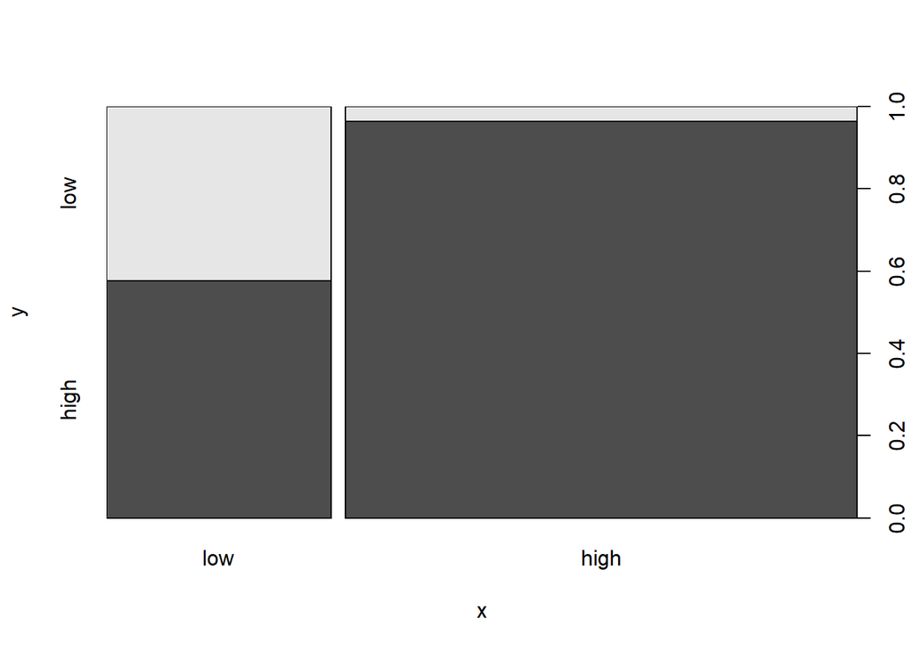

```r
plot(data_test$Cutaneous.Leishmaniasis, data_test$.pred_class)
```

Looking at the Separate Accurracies of each base model in the stacked model.

```r
# confusion matrix for base models

member_preds <-
  data_test %>%
  select(Cutaneous.Leishmaniasis) %>%
  bind_cols(
    predict(
      model_st,
      data_test,
      members = TRUE
    )
  )


colnames(member_preds) %>%
  map_dfr(
    .f = accuracy,
    truth = Cutaneous.Leishmaniasis,
    data = member_preds
  ) %>%
  mutate(member = colnames(member_preds))
```

```
## # A tibble: 4 × 4
##   .metric  .estimator .estimate member
##   <chr>    <chr>          <dbl> <chr>
## 1 accuracy binary         1     Cutaneous.Leishmaniasis
## 2 accuracy binary         0.799 .pred_class
## 3 accuracy binary         0.824 .pred_class_xgb_res_1_5
## 4 accuracy binary         0.826 .pred_class_rf_res_1_5
```